# Operations on shapes

Vincent Bonhomme

2018-10-28

## Preamble

In Momocs, a shape is a matrix of `(x, y)` coordinates. When they are plenty, they are usually gathered in a `Coo` object which is, essentially, a list with at least a `$coo` component.

```r
library(Momocs)
```

```r
# a single shape
bot[1] %>% is_shp() # tests if it is a 2-col matrix without NAs
```

```
## [1] TRUE
```

```r
bot[1] %>% head()
```

```
##      [,1] [,2]
## [1,]   37  561
## [2,]   40  540
## [3,]   40  529
## [4,]   43  508
## [5,]   46  487
## [6,]   48  477
```

```r
# a collection of shapes
bot %>% class()     # Out for outlines, but also a Coo. See ?Coo
```

```
## [1] "Out" "Coo"
```

```r
bot %>% is.list()   # essentially a list
```

```
## [1] TRUE
```

```r
bot$coo %>% class() # with a $coo component
```

```
## [1] "list"
```

```r
bot$coo[1:2] %>% lapply(head) # where shapes are gathered
```

```
## $brahma
##      [,1] [,2]
## [1,]   37  561
## [2,]   40  540
## [3,]   40  529
## [4,]   43  508
## [5,]   46  487
## [6,]   48  477
##
## $caney
##      [,1] [,2]
## [1,]   53  535
## [2,]   53  525
## [3,]   54  505
## [4,]   53  495
## [5,]   54  485
## [6,]   54  464
```

Most operations on shapes can also be done on `Coo` objects. For example, getting the area or centering:

```r
coo_area(bot[1]) # in pixels^2
```

```
## [1] 234515
```

```r
coo_area(bot) %>% head()
```

```
##      brahma       caney      chimay      corona deusventrue       duvel
##    234515.0    201056.5    119459.5    119568.5    165735.5    114015.0
```

In other words most `coo_` functions are actually *methods* that can actually be passed with a single matrix or a Coo object.

Below, we will distinguish `coo_*` operations based on whether they return a shape (eg if it is a geometric operation) or a scalar (a single number that can be used as a shape descriptor).

Not all are described but you can obtain a full list of `coo_` operations with:

```r
cool <- apropos("coo_") # get the full list
head(cool)              # the firt 6
```

```
## [1] ".coo_angle_edge1"      "coo_align"             "coo_align.Coo"
## [4] "coo_align.default"     "coo_aligncalliper"     "coo_aligncalliper.Coo"
```

```r
length(cool)            # how many are defined
```

```
## [1] 275
```

## Scalar descriptors of shape

`coo_scalar` calculate *all* scalar descriptors included in Momocs. `coo_rectilinearity` is not included by default since it takes a looot of time to compute.

```r
df <- shapes %>% coo_scalars()
df
```

```
## # A tibble: 30 x 15
##      area calliper centsize circularity circularityharali… circularitynorm
##     <dbl>    <dbl>    <dbl>       <dbl>              <dbl>           <dbl>
##  1 20030.     319.     87.9        54.4               2.21            4.33
##  2 26078.     311.    103.         32.0               2.47            2.55
##  3 31516      280.     91.2        51.1               2.43            4.07
##  4 14180.     231.     73.0        46.6               2.84            3.71
##  5  9282.     206.     63.4        41.8               2.33            3.32
##  6 24060.     263.     91.2        35.9               3.84            2.85
##  7 14940.     263.     81.5        52.0               2.74            4.14
##  8 33921      352.    109.         35.7               2.83            2.84
##  9 18654      209.     67.3        74.1               2.45            5.89
## 10 36654.     312.     98.3       106.                2.72            8.45
## # ... with 20 more rows, and 9 more variables: convexity <dbl>,
## #   eccentricityboundingbox <dbl>, eccentricityeigen <dbl>,
## #   elongation <dbl>, length <dbl>, perim <dbl>, rectangularity <dbl>,
## #   solidity <dbl>, width <dbl>
```

Each of the function listed below has its own method that you can used by prefixing it with `coo_`; see the example below with `coo_area`.

```r
colnames(df) %>% cat(sep="\n")
```

```
## area
## calliper
## centsize
## circularity
## circularityharalick
## circularitynorm
## convexity
## eccentricityboundingbox
## eccentricityeigen
## elongation
## length
## perim
## rectangularity
## solidity
## width
```

```r
coo_area(shapes[4]) # in pixels^2
```

```
## [1] 14180.5
```

```r
coo_area(shapes)
```

```
##    arrow     bone buttefly      cat    check    cross      dog     fish
##  20029.5  26078.5  31516.0  14180.5   9281.5  24060.5  14939.5  33921.0
##     hand    hands    heart     info     lady     leaf    leaf2    leaf3
##  18654.0  36653.5  24276.5   8453.5  11541.0  12861.5  16993.5  18301.5
##    leaf4     moon    morph   parrot    penta   pigeon    plane   puzzle
##  17748.5  13558.0  28292.0   7894.5  24709.0  23792.5  12649.0  16986.5
##   rabbit  sherrif    snail     star    tetra umbrella
##  18915.5  15766.0  26992.5  23132.0  18119.0  16878.5
```

```r
# a subset
dplyr::data_frame(area=coo_area(shapes),
                  perim=coo_perim(shapes)) %>% head()
```

```
## # A tibble: 6 x 2
##     area perim
##    <dbl> <dbl>
## 1 20030. 1044.
## 2 26078.  914.
## 3 31516  1269.
## 4 14180.  813.
## 5  9282.  623.
## 6 24060.  929.
```

## Geometric operations

The functions below return shapes, so we exemplify them with graphs. For the sake of clarity/speed we illustrate them on single shape but, again, this can be done on `Coo` objects.

```r
# A single example on Coo
bot %>% stack
```

```
## will soon be deprecated, see ?pile
```

[figure not shown]

```r
bot %>% coo_center %>% stack()
```

```
## will soon be deprecated, see ?pile
```

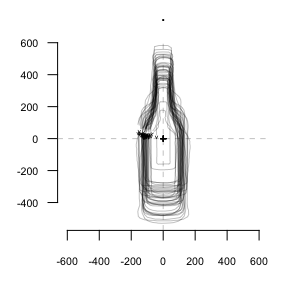

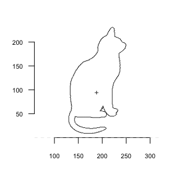

```r
shp <- shapes[4]
shp %>% coo_plot()
```

### Size

#### Isotropic

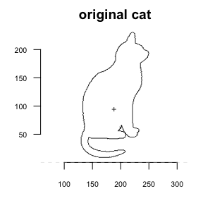

```r
shp %>% coo_plot(main="original cat")
```

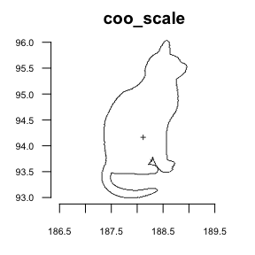

```r
# scaling
shp %>% coo_scale %>% coo_plot(main="coo_scale")
```

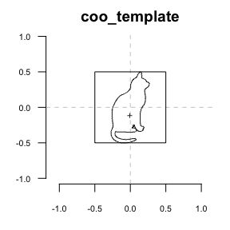

```r
# templating
shp %>% coo_template(1) %>% coo_plot(ylim=c(-1, 1), main="coo_template"); rect(-0.5, -0.5, 0.5, 0.5)
```

#### Anisotropic

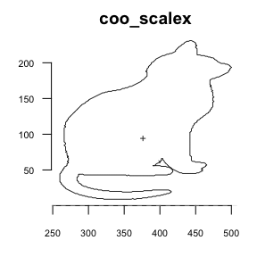

```r
shp %>% coo_scalex(2) %>% coo_plot(main="coo_scalex")
```

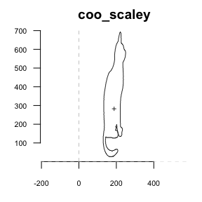

```r
shp %>% coo_scaley(3) %>% coo_plot(main="coo_scaley")
```

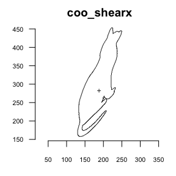

```r
shp %>% coo_shearx(1) %>% coo_plot(main="coo_shearx")
```

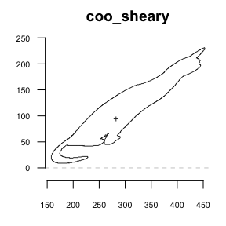

```r
shp %>% coo_sheary(1) %>% coo_plot(main="coo_sheary")
```

### Alignment

#### Based on geometry

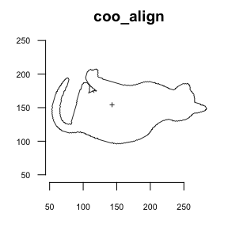

```r
shp %>% coo_align          %>% coo_plot(main="coo_align")
```

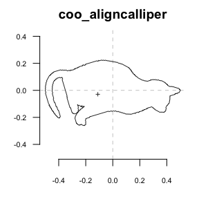

```r
shp %>% coo_aligncalliper  %>% coo_plot(main="coo_aligncalliper")
```

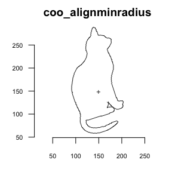

```r
shp %>% coo_alignminradius %>% coo_plot(main="coo_alignminradius")
```

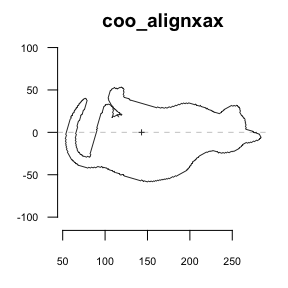

```r
shp %>% coo_alignxax       %>% coo_plot(main="coo_alignxax")
```

#### Based on landmarks

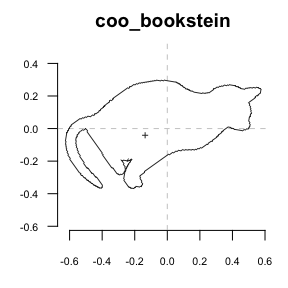

```r
# we use points with id 93 and 516 as landmarks
coo_bookstein(shp, 93, 516) %>% coo_plot(main="coo_bookstein")
```

```r
# see coo_baseline for a more generic version
```

### Translation

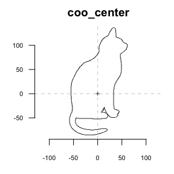

```r
shp %>% coo_center %>% coo_plot(main="coo_center") # or coo_centre if you come from UK
```

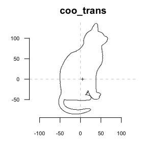

```r
shp %>% coo_center %>% coo_trans(x=  5) %>% coo_plot(main="coo_trans")
```

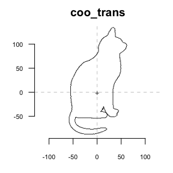

```r
shp %>% coo_center %>% coo_trans(y= -2) %>% coo_plot(main="coo_trans")
```

### Rotation

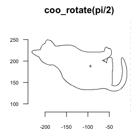

```r
shp %>% coo_rotate(pi/2) %>% coo_plot(main="coo_rotate(pi/2)")
```

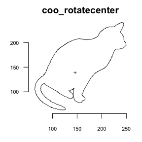

```r
shp %>% coo_rotatecenter(-pi/6, center=c(250, 195)) %>% coo_plot(main="coo_rotatecenter") # with center ~on cat's nose
```

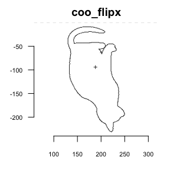

```r
# mirrorring
shp %>% coo_flipx %>% coo_plot(main="coo_flipx")
```

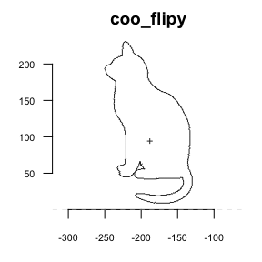

```r
shp %>% coo_flipy %>% coo_plot(main="coo_flipy")
```

### Sampling

```r
shp %>% coo_nb()
```

```
## [1] 710
```

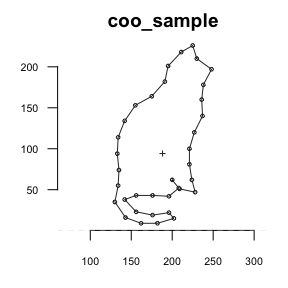

```r
shp %>% coo_sample(36) %>% coo_plot(main="coo_sample")
shp %>% coo_sample_prop(1/20) %>%  coo_plot(main="coo_sample")
```

[output not shown]

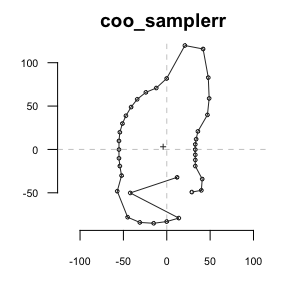

```r
shp %>% coo_samplerr(36) %>% coo_plot(main="coo_samplerr") # regular radius
```

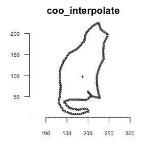

```r
shp %>% coo_sample(36) %>% coo_interpolate(144) %>% coo_plot(points=TRUE, main="coo_interpolate")
```

### Smoothing

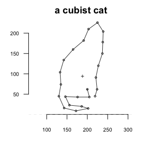

```r
shp %>% coo_sample(24) %>% coo_plot(main="a cubist cat")
```

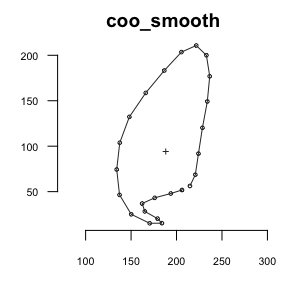

```r
shp %>% coo_sample(24) %>% coo_smooth(2) %>% coo_plot(main="coo_smooth")
```

If you have curves, you may prefer not to change first and last points:

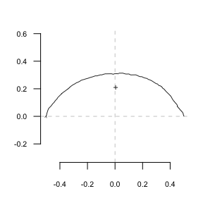

```r
olea[1] %>% coo_plot()
```

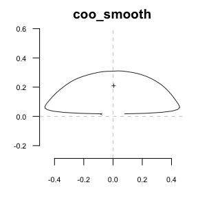

```r
olea[1] %>% coo_smooth(12) %>% coo_plot(main="coo_smooth")
```

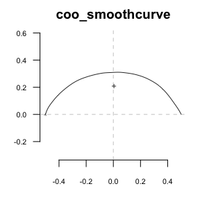

```r
olea[1] %>% coo_smoothcurve(12) %>% coo_plot(main="coo_smoothcurve")
```